# Titanic_Survivor_Prediction_Pipeline

## End to End Pipeline: Titanic Survivors example

By Matthew Hill 31/03/2020

Using the Titanic dataset from [this](https://www.kaggle.com/c/titanic/overview) Kaggle competition.

This dataset contains information about 891 people who were on board the ship when departed on April 15th, 1912. As noted in the description on Kaggle's website, some people aboard the ship were more likely to survive the wreck than others. There were not enough lifeboats for everybody so women, children, and the upper-class were prioritized. Using the information about these 891 passengers, the challenge is to build a model to predict which people would survive based on the following fields:

- **Name** (str) - Name of the passenger
- **Pclass** (int) - Ticket class
- **Sex** (str) - Sex of the passenger
- **Age** (float) - Age in years
- **SibSp** (int) - Number of siblings and spouses aboard
- **Parch** (int) - Number of parents and children aboard
- **Ticket** (str) - Ticket number
- **Fare** (float) - Passenger fare
- **Cabin** (str) - Cabin number
- **Embarked** (str) - Port of embarkation (C = Cherbourg, Q = Queenstown, S = Southampton)

### Process

1. Explore and clean the data
2. Split data into train / validation / test data
3. Fit an initial model and evaluate
4. Tune hyperparameters
5. Evaluate 3 most promising models on validation set
6. Final model selection and evaluation on test set

### Read in Data

```python
import matplotlib.pyplot as plt
import pandas as pd
import seaborn as sns
import numpy as np

from sklearn.model_selection import train_test_split
from sklearn.ensemble import RandomForestClassifier
from sklearn.model_selection import cross_val_score
from sklearn.model_selection import GridSearchCV
from sklearn.metrics import accuracy_score, precision_score, recall_score

import warnings
warnings.filterwarnings("ignore", category=FutureWarning)

%matplotlib inline

titanic = pd.read_csv('titanic.csv')
titanic.head(10)
```

|  | PassengerId | Survived | Pclass | Name | Sex | Age | SibSp | Parch | Ticket | Fare | Cabin | Embarked |
| --- | --- | --- | --- | --- | --- | --- | --- | --- | --- | --- | --- | --- |
| 0 | 1 | 0 | 3 | Braund, Mr. Owen Harris | male | 22.0 | 1 | 0 | A/5 21171 | 7.2500 | NaN | S |
| 1 | 2 | 1 | 1 | Cumings, Mrs. John Bradley (Florence Briggs Th... | female | 38.0 | 1 | 0 | PC 17599 | 71.2833 | C85 | C |
| 2 | 3 | 1 | 3 | Heikkinen, Miss. Laina | female | 26.0 | 0 | 0 | STON/O2. 3101282 | 7.9250 | NaN | S |
| 3 | 4 | 1 | 1 | Futrelle, Mrs. Jacques Heath (Lily May Peel) | female | 35.0 | 1 | 0 | 113803 | 53.1000 | C123 | S |
| 4 | 5 | 0 | 3 | Allen, Mr. William Henry | male | 35.0 | 0 | 0 | 373450 | 8.0500 | NaN | S |
| 5 | 6 | 0 | 3 | Moran, Mr. James | male | NaN | 0 | 0 | 330877 | 8.4583 | NaN | Q |
| 6 | 7 | 0 | 1 | McCarthy, Mr. Timothy J | male | 54.0 | 0 | 0 | 17463 | 51.8625 | E46 | S |
| 7 | 8 | 0 | 3 | Palsson, Master. Gosta Leonard | male | 2.0 | 3 | 1 | 349909 | 21.0750 | NaN | S |
| 8 | 9 | 1 | 3 | Johnson, Mrs. Oscar W (Elisabeth Vilhelmina Berg) | female | 27.0 | 0 | 2 | 347742 | 11.1333 | NaN | S |
| 9 | 10 | 1 | 2 | Nasser, Mrs. Nicholas (Adele Achem) | female | 14.0 | 1 | 0 | 237736 | 30.0708 | NaN | C |

### Clean continuous variables

1. Fill in missing values for `Age`
2. Combine `SibSp` & `Parch`
3. Drop irrelevant/repetitive variables (`SibSp`, `Parch`, `PassengerId`)

#### Fill missing for `Age`

```python
titanic.isnull().sum()
```

```
PassengerId      0
Survived         0
Pclass           0
Name             0
Sex              0
Age            177
SibSp            0
Parch            0
Ticket           0
Fare             0
Cabin          687
Embarked         2
dtype: int64
```

```python
titanic['Age'].fillna(titanic['Age'].mean(), inplace=True)
```

If no Age is noted then we give them the average age value to not Bias the dataset

#### Combine `SibSp` & `Parch`

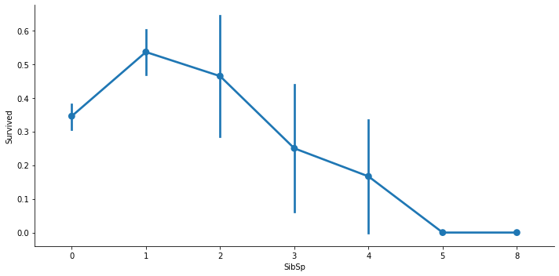

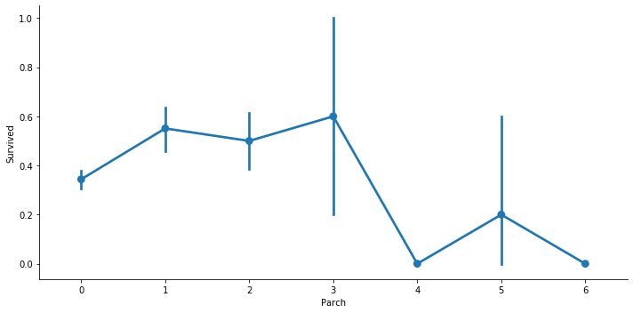

```python
for i, col in enumerate(['SibSp', 'Parch']):
    plt.figure(i)
    sns.catplot(x=col, y='Survived', data=titanic, kind='point', aspect=2, )
```

```python
titanic['Family_cnt'] = titanic['SibSp'] + titanic['Parch']
```

#### Drop unnnecessary variables

```python
titanic.drop(['PassengerId', 'SibSp', 'Parch'], axis=1, inplace=True)
```

```python
titanic.head(10)
```

|  | Survived | Pclass | Name | Sex | Age | Ticket | Fare | Cabin | Embarked | Family_cnt |
| --- | --- | --- | --- | --- | --- | --- | --- | --- | --- | --- |
| 0 | 0 | 3 | Braund, Mr. Owen Harris | male | 22.000000 | A/5 21171 | 7.2500 | NaN | S | 1 |
| 1 | 1 | 1 | Cumings, Mrs. John Bradley (Florence Briggs Th... | female | 38.000000 | PC 17599 | 71.2833 | C85 | C | 1 |
| 2 | 1 | 3 | Heikkinen, Miss. Laina | female | 26.000000 | STON/O2. 3101282 | 7.9250 | NaN | S | 0 |
| 3 | 1 | 1 | Futrelle, Mrs. Jacques Heath (Lily May Peel) | female | 35.000000 | 113803 | 53.1000 | C123 | S | 1 |
| 4 | 0 | 3 | Allen, Mr. William Henry | male | 35.000000 | 373450 | 8.0500 | NaN | S | 0 |
| 5 | 0 | 3 | Moran, Mr. James | male | 29.699118 | 330877 | 8.4583 | NaN | Q | 0 |
| 6 | 0 | 1 | McCarthy, Mr. Timothy J | male | 54.000000 | 17463 | 51.8625 | E46 | S | 0 |
| 7 | 0 | 3 | Palsson, Master. Gosta Leonard | male | 2.000000 | 349909 | 21.0750 | NaN | S | 4 |
| 8 | 1 | 3 | Johnson, Mrs. Oscar W (Elisabeth Vilhelmina Berg) | female | 27.000000 | 347742 | 11.1333 | NaN | S | 2 |
| 9 | 1 | 2 | Nasser, Mrs. Nicholas (Adele Achem) | female | 14.000000 | 237736 | 30.0708 | NaN | C | 1 |

### Clean categorical variables

1. Create an indicator variable in place of `Cabin`
2. Convert `Sex` to a numeric variable
3. Drop irrelevant/repetitive variables (`Cabin`, `Embarked`, `Name`, `Ticket`)

#### Create indicator for `Cabin`

```python
titanic['Cabin_ind'] = np.where(titanic['Cabin'].isnull(), 0, 1)
```

People without a cabin number most likely didn't have one so if its null then we assign it 0

#### Convert `Sex` to numeric

```python
gender_num = {'male': 0, 'female': 1}

titanic['Sex'] = titanic['Sex'].map(gender_num)
```

#### Drop unnecessary variables

```python
titanic.drop(['Cabin', 'Embarked', 'Name', 'Ticket'], axis=1, inplace=True)
titanic.head()
```

|  | Survived | Pclass | Sex | Age | Fare | Family_cnt | Cabin_ind |
| --- | --- | --- | --- | --- | --- | --- | --- |
| 0 | 0 | 3 | 0 | 22.0 | 7.2500 | 1 | 0 |
| 1 | 1 | 1 | 1 | 38.0 | 71.2833 | 1 | 1 |
| 2 | 1 | 3 | 1 | 26.0 | 7.9250 | 0 | 0 |
| 3 | 1 | 1 | 1 | 35.0 | 53.1000 | 1 | 1 |
| 4 | 0 | 3 | 0 | 35.0 | 8.0500 | 0 | 0 |

### Write out cleaned data

```python
titanic.to_csv('titanic_cleaned.csv', index=False)
```

```python
titanic = pd.read_csv('titanic_cleaned.csv')
```

### Split into train, validation, and test set

```python
features = titanic.drop('Survived', axis=1)
labels = titanic['Survived']

X_train, X_test, y_train, y_test = train_test_split(features, labels, test_size=0.4, random_state=42)
X_test, X_val, y_test, y_val = train_test_split(X_test, y_test, test_size=0.5, random_state=42)
```

```python
for dataset in [y_train, y_val, y_test]:
    print(round(len(dataset) / len(labels), 2))
```

```
0.6
0.2
0.2
```

### Write out data

```python
X_train.to_csv('train_features.csv', index=False)
X_val.to_csv('val_features.csv', index=False)
X_test.to_csv('test_features.csv', index=False)

y_train.to_csv('train_labels.csv', index=False)
y_val.to_csv('val_labels.csv', index=False)
y_test.to_csv('test_labels.csv', index=False)
```

### Fit and evaluate a basic model using 5-fold Cross-Validation

```python
tr_features = pd.read_csv('train_features.csv')
tr_labels = pd.read_csv('train_labels.csv', header=None)
```

```python
rf = RandomForestClassifier()
scores = cross_val_score(rf, tr_features, tr_labels.values.ravel(), cv=5)
```

```python
scores
```

```
array([0.87037037, 0.77570093, 0.77570093, 0.81132075, 0.82075472])
```

These are with default hyperparameter settings

### Hyperparameter tuning

```python
def print_results(results):
    print('BEST PARAMS: {}\n'.format(results.best_params_))

    means = results.cv_results_['mean_test_score']
    stds = results.cv_results_['std_test_score']
    for mean, std, params in zip(means, stds, results.cv_results_['params']):
        print('{} (+/-{}) for {}'.format(round(mean, 3), round(std * 2, 3), params))
```

```python
rf = RandomForestClassifier()
parameters = {
    'n_estimators': [5, 50, 100],
    'max_depth': [2, 10, 20, None]
}

cv = GridSearchCV(rf, parameters, cv=5)
cv.fit(tr_features, tr_labels.values.ravel())

print_results(cv)
```

```
BEST PARAMS: {'max_depth': 10, 'n_estimators': 50}

0.779 (+/-0.126) for {'max_depth': 2, 'n_estimators': 5}
0.811 (+/-0.113) for {'max_depth': 2, 'n_estimators': 50}
0.801 (+/-0.109) for {'max_depth': 2, 'n_estimators': 100}
0.811 (+/-0.058) for {'max_depth': 10, 'n_estimators': 5}
0.822 (+/-0.049) for {'max_depth': 10, 'n_estimators': 50}
0.818 (+/-0.052) for {'max_depth': 10, 'n_estimators': 100}
0.794 (+/-0.034) for {'max_depth': 20, 'n_estimators': 5}
0.816 (+/-0.025) for {'max_depth': 20, 'n_estimators': 50}
0.809 (+/-0.019) for {'max_depth': 20, 'n_estimators': 100}
0.796 (+/-0.064) for {'max_depth': None, 'n_estimators': 5}
0.805 (+/-0.021) for {'max_depth': None, 'n_estimators': 50}
0.805 (+/-0.019) for {'max_depth': None, 'n_estimators': 100}
```

We now select the top 3 most promising models hyperparameters

1. 'max_depth' = 10 ; 'n_estimators': 50' Score = 0.822
2. 'max_depth' = 10 ; 'n_estimators': 100' Score = 0.818
3. 'max_depth' = 20 ; 'n_estimators': 50' Score = 0.816

### Fit best models on full training set

```python
val_features = pd.read_csv('val_features.csv')
val_labels = pd.read_csv('val_labels.csv', header=None)

te_features = pd.read_csv('test_features.csv')
te_labels = pd.read_csv('test_labels.csv', header=None)
```

```python
rf1 = RandomForestClassifier(n_estimators=50, max_depth=10)
rf1.fit(tr_features, tr_labels.values.ravel())

rf2 = RandomForestClassifier(n_estimators=100, max_depth=10)
rf2.fit(tr_features, tr_labels.values.ravel())

rf3 = RandomForestClassifier(n_estimators=50, max_depth=20)
rf3.fit(tr_features, tr_labels.values.ravel())
```

```
RandomForestClassifier(bootstrap=True, class_weight=None, criterion='gini',
                       max_depth=20, max_features='auto', max_leaf_nodes=None,
                       min_impurity_decrease=0.0, min_impurity_split=None,
                       min_samples_leaf=1, min_samples_split=2,
                       min_weight_fraction_leaf=0.0, n_estimators=50,
                       n_jobs=None, oob_score=False, random_state=None,
                       verbose=0, warm_start=False)
```

### Evaluate models on validation set

```python
for mdl in [rf1, rf2, rf3]:
    y_pred = mdl.predict(val_features)
    accuracy = round(accuracy_score(val_labels, y_pred), 3)
    precision = round(precision_score(val_labels, y_pred), 3)
    recall = round(recall_score(val_labels, y_pred), 3)
    print('MAX DEPTH: {} / # OF EST: {} -- A: {} / P: {} / R: {}'.format(mdl.max_depth,
                                                                         mdl.n_estimators,
                                                                         accuracy,
                                                                         precision,
                                                                         recall))
```

```
MAX DEPTH: 10 / # OF EST: 50 -- A: 0.827 / P: 0.857 / R: 0.711
MAX DEPTH: 10 / # OF EST: 100 -- A: 0.827 / P: 0.846 / R: 0.724
MAX DEPTH: 20 / # OF EST: 50 -- A: 0.804 / P: 0.806 / R: 0.711
```

So best model is rf2 (MAX DEPTH: 10 / # OF EST: 100)

### Evaluate the best model on the test set

```python
y_pred = rf2.predict(te_features)
accuracy = round(accuracy_score(te_labels, y_pred), 3)
precision = round(precision_score(te_labels, y_pred), 3)
recall = round(recall_score(te_labels, y_pred), 3)
print('MAX DEPTH: {} / # OF EST: {} -- A: {} / P: {} / R: {}'.format(rf2.max_depth,
                                                                     rf2.n_estimators,
                                                                     accuracy,
                                                                     precision,
                                                                     recall))
```

```
MAX DEPTH: 10 / # OF EST: 100 -- A: 0.792 / P: 0.75 / R: 0.646
```